# EmpatIA · informe longitudinal

Cuatro ediciones del estudio, leídas como una sola historia

# De qué se trata

El estudio EmpatIA se levanta todos los años con personas distintas. Cada edición responde **cómo está el mercado**: qué esperan las personas de una marca, qué marcas logran el mejor equilibrio entre humanidad y tecnología, quién gana en cada industria.

Este informe responde otra cosa: **hacia dónde va**. Recorre las mismas preguntas del informe anual —el mismo orden, las mismas láminas— pero con el eje del tiempo encima.

4 ediciones · 119 marcas con historia comparable · 23 atributos medidos igual todos los años

Una advertencia que vale para todo lo que sigue: cada edición es una muestra distinta, así que **una diferencia pequeña entre dos años puede ser quién contestó esta vez**. En cada lámina se indica cuándo un cambio supera ese margen y cuándo no.

# Las cuatro muestras

Antes de comparar nada hay que mirar a quién se le preguntó cada vez. Si la composición de las muestras se mueve, parte de lo que parece cambio del mercado es cambio de la muestra.

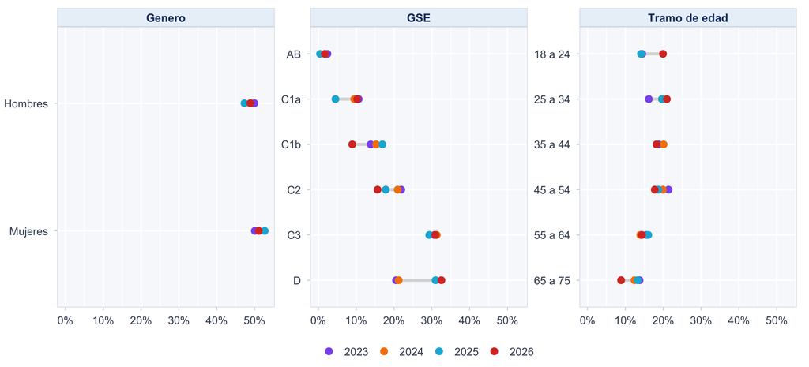

**Las muestras no son idénticas, y conviene saberlo antes de leer el resto.** La composición socioeconómica se corrió: **D** se mueve 12,0 puntos, **C1b** se mueve 8,0 puntos, **C2** se mueve 6,3 puntos, **C1a** se mueve 6,1 puntos. Edad y género, en cambio, se mueven a lo más 5,8 puntos. Un cambio de nivel del mercado entre ediciones puede venir en parte de ahí, y por eso este informe se apoya en el **orden** —quién le gana a quién— más que en el nivel absoluto: el orden es mucho menos sensible a con quién se llenó la cuota.

# Qué esperan las personas de una marca

La escala de importancia tiende a subir para todo, así que el nivel dice poco. Lo que se puede seguir es el **orden**: qué atributo le gana a cuál, año a año.

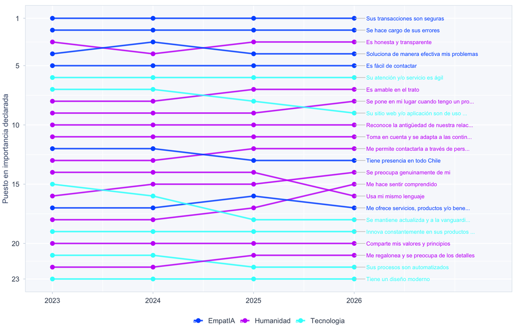

# Lo que cambió en el contexto

Las expectativas sobre las marcas y la actitud frente a la tecnología sí se mueven, y ahí está buena parte de la historia de estos años.

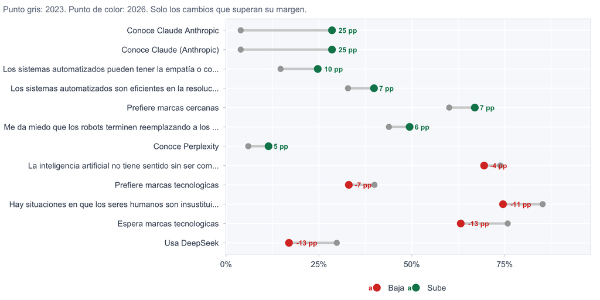

# El ranking en el tiempo

Un puesto sin su historia no dice si la marca viene subiendo o cayendo. Estas tres láminas son el mismo ranking del informe anual, leído como trayectoria.

## Las que están arriba, año a año

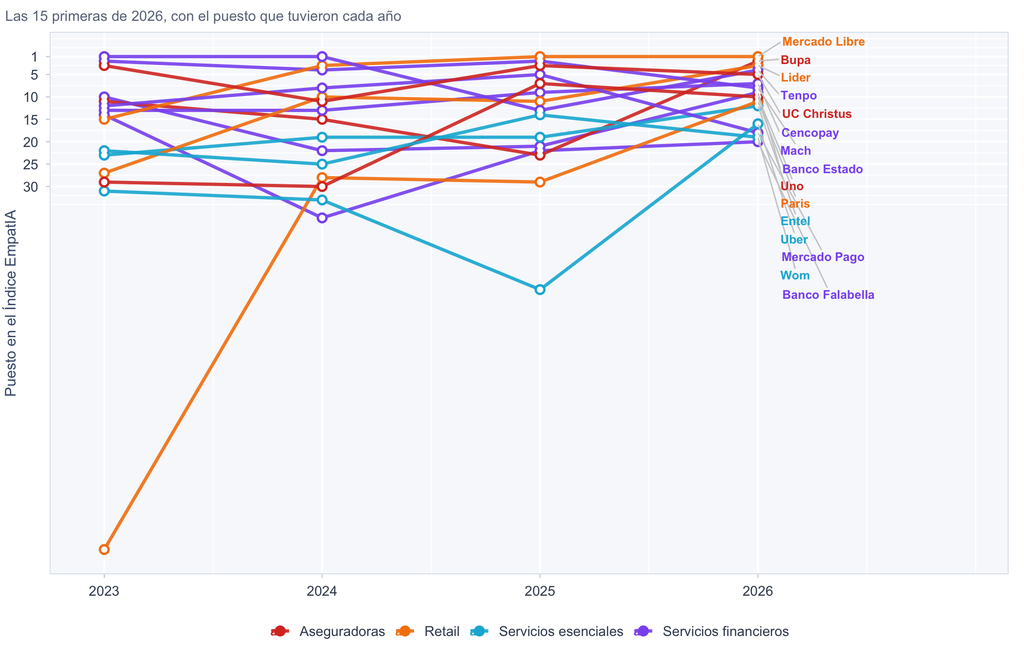

## De qué tramo a qué tramo

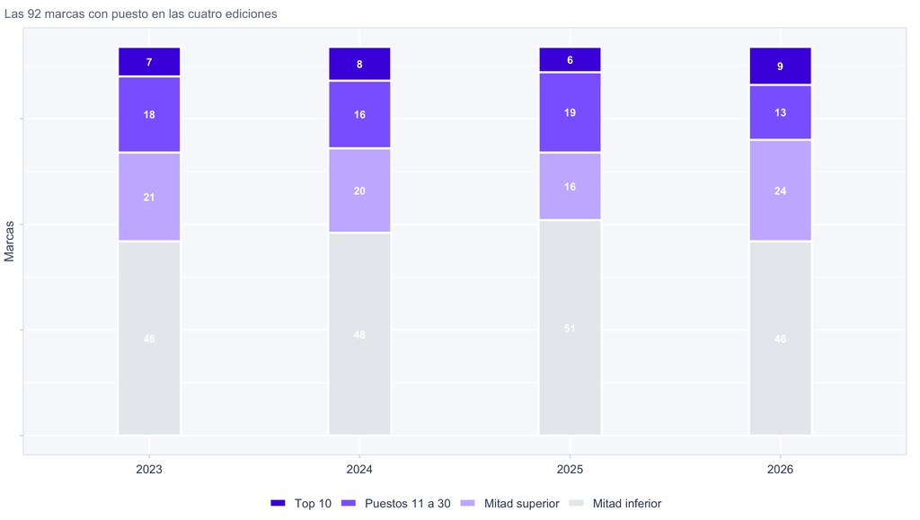

El mercado se mueve, pero **por dentro**. De 92 marcas con historia completa, 38 nunca salieron de su tramo, 19 subieron para quedarse, 16 bajaron y 19 fueron y volvieron. La élite del ranking cambia poco; la pelea está en el medio.

## Quién ganó y quién perdió puestos

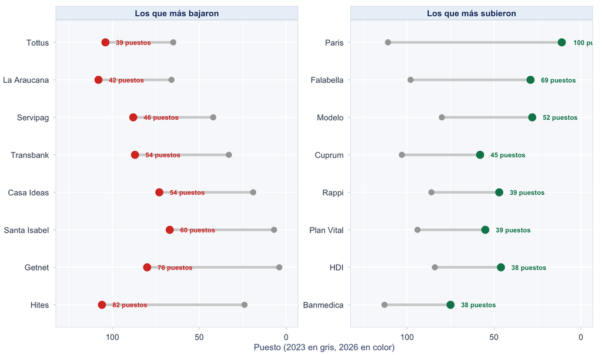

## Cuánto de eso es movimiento real

Un cambio de puesto puede venir de que la marca se movió o de que le tocaron otras personas. La única forma de distinguirlos es comparar el cambio contra su propio margen.

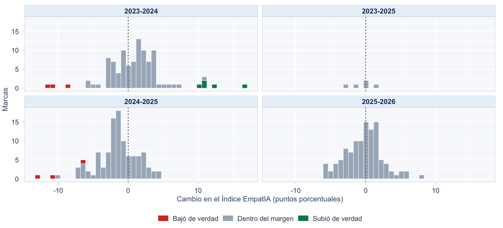

De 322 transiciones marca-año, solo **11 superan el margen de la medición** —por puro azar se esperarían 16—. El mercado EmpatIA es lento: la mayor parte de lo que parece movimiento, no lo es.

## Cómo se reparte el mercado cada año

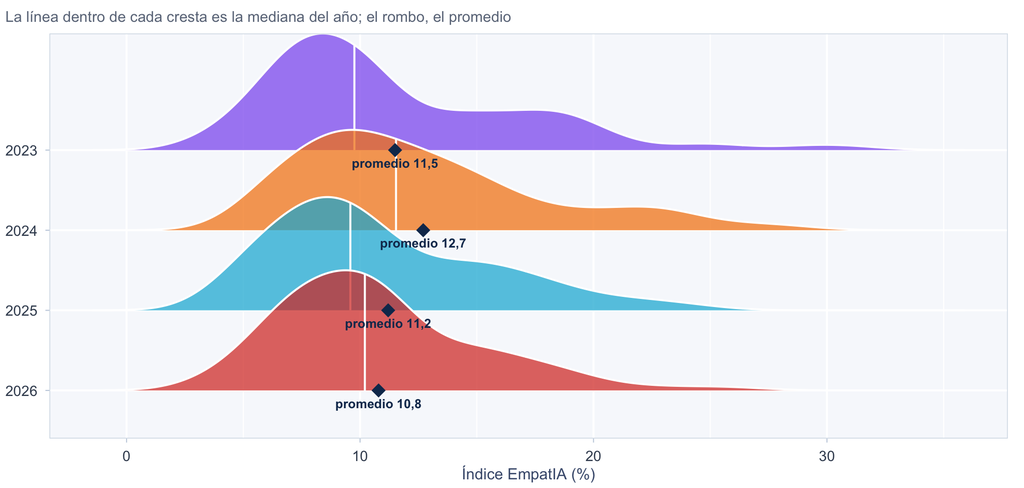

El Índice EmpatIA promedio de las marcas pasó de 11,5 en 2023 a 10,8 en 2026, un cambio dentro del margen de las dos encuestas. La mediana del mercado pasó de 9,7% a 10,2%, y la distancia entre las marcas se cerró: la dispersión va de 5,6 a 4,3 puntos. El mercado se está pareciendo más a sí mismo.

# El recorrido: conocer, usar, preferir

El informe anual muestra este embudo marca por marca. En el tiempo importa otra cosa: si el mercado entero se volvió más fácil o más difícil de convertir.

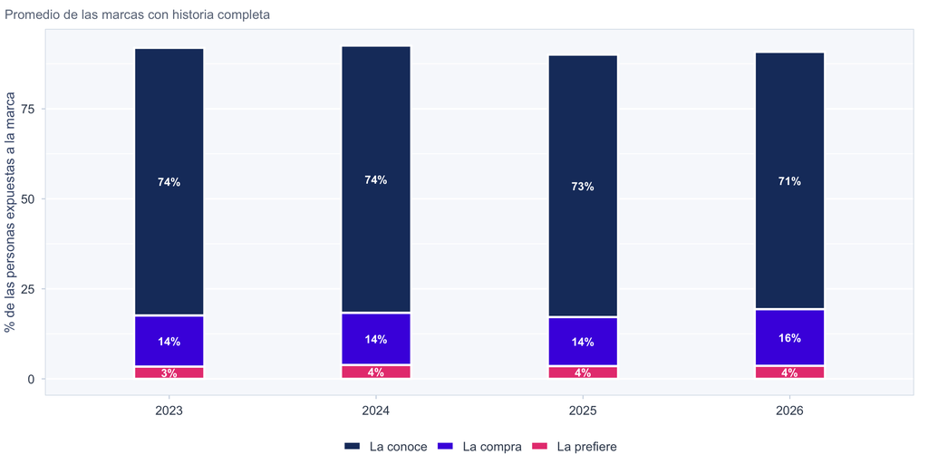

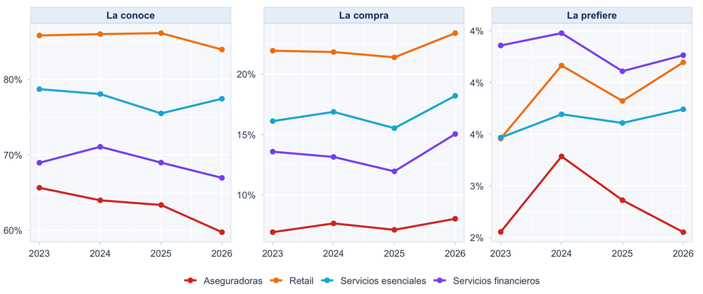

# El mapa común y las trayectorias

Las cuatro ediciones se proyectan sobre un mismo mapa, calculado con los atributos que existen en todas. Así, una marca que se mueve en el dibujo se movió de verdad, y no porque el mapa cambió debajo de ella.

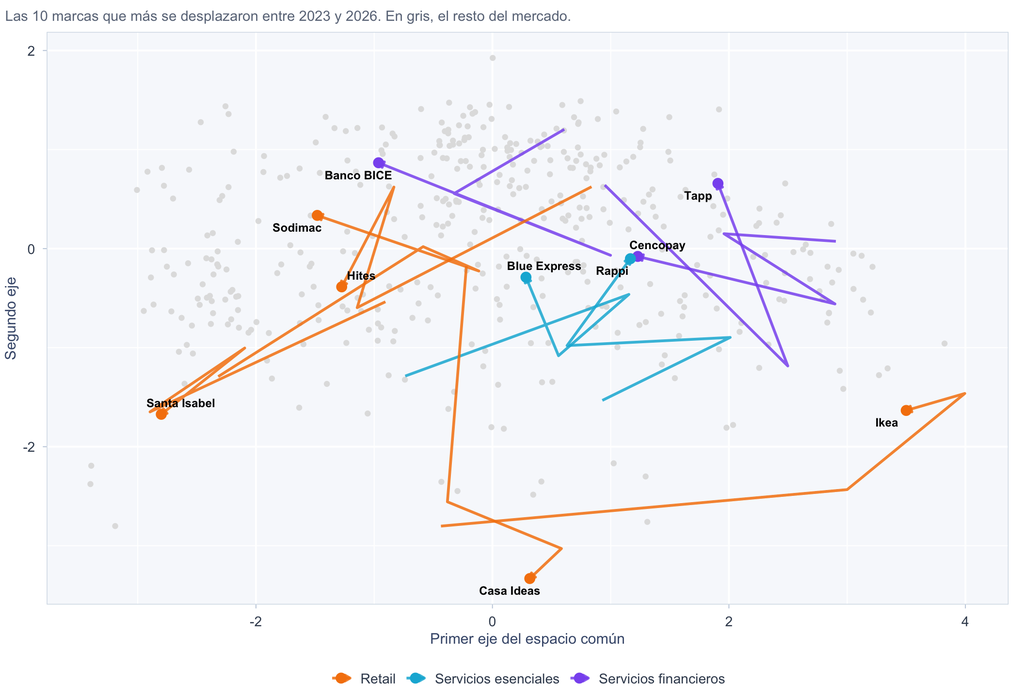

# Qué mueve la preferencia, y si sigue siendo lo mismo

La importancia **derivada** sale del modelo de elección: qué atributo hace que una marca gane, no cuál dice la gente que le importa. Si cambiara todos los años, ninguna estrategia de marca duraría más de una edición.

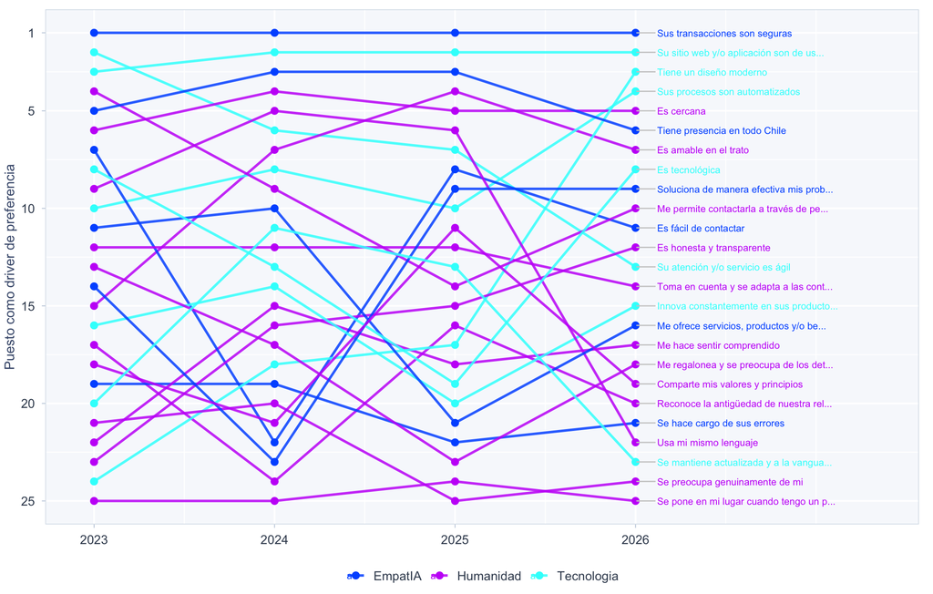

Lo que mueve la preferencia **se parece de un año a otro, sin ser idéntico**: la correlación media entre el orden de dos ediciones es de 0,63. «Sus transacciones son seguras» no se mueve del puesto 1 en ninguna edición.

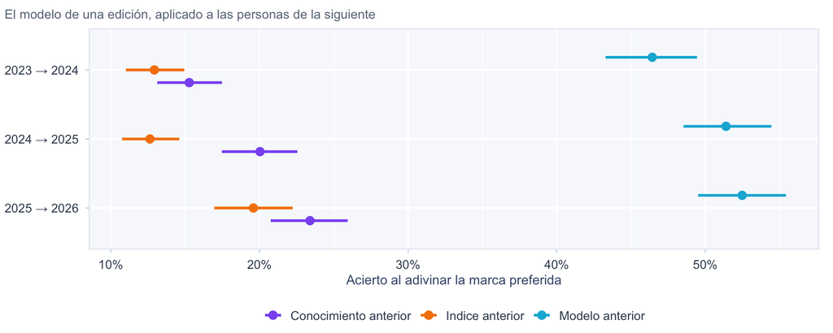

# Las personas y la inteligencia artificial

El bloque empezó a medirse en 2025, así que su serie tiene dos puntos. Con dos puntos no hay tendencia, pero sí hay diferencia —y es la parte del estudio que se está moviendo más rápido—.

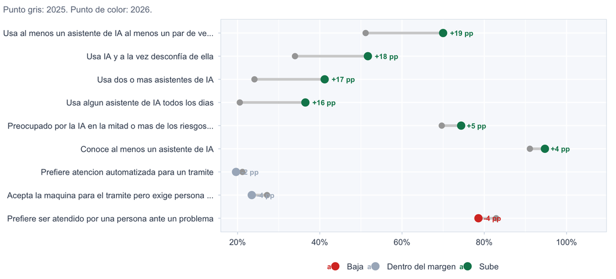

En un solo año, 7 de 9 indicadores cambiaron por sobre su margen. El mayor movimiento es **Usa al menos un asistente de IA al menos un par de veces …**: 51% → 70%. Ningún otro bloque del estudio se mueve a esta velocidad.

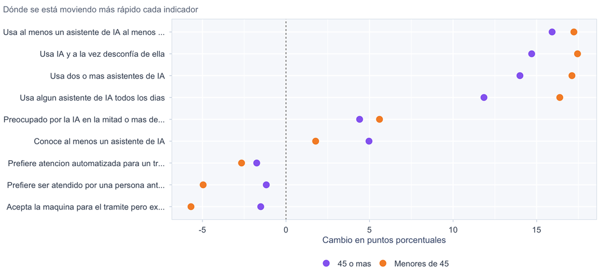

# Qué tan sólido es todo esto

Tres pruebas que este informe se hace a sí mismo antes de afirmar nada.

[output not shown]

**La confiabilidad del nivel** dice cuánta de la diferencia entre marcas es real y cuánta es medición: cerca de 1 significa que el ranking distingue de verdad. **La confiabilidad del cambio** hace lo mismo con el movimiento de una edición a la siguiente, y siempre es más baja —una diferencia de diferencias arrastra dos márgenes—. Por eso este informe exige que un cambio supere su margen antes de llamarlo cambio.

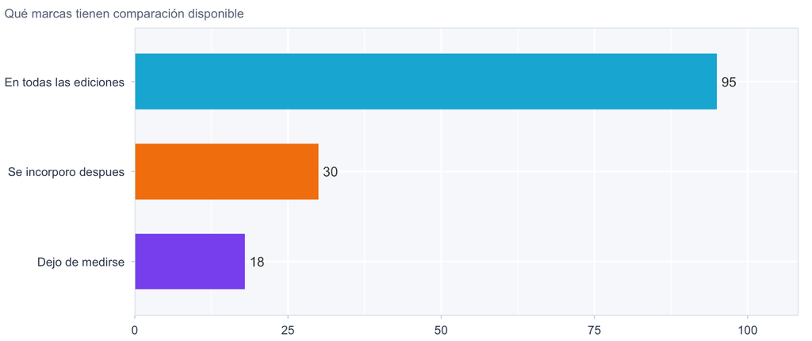

# Cómo llevarlo a decisiones

**Un cambio sin margen no es un cambio.** De cada cien movimientos aparentes entre dos ediciones, 3 superan su margen: el resto cabe dentro de lo que explica la muestra. Cuando este informe dice «se movió de verdad», es porque el cambio superó su propio margen.

**Donde sí hay que correr es en inteligencia artificial.** Es el bloque del estudio donde un año hace la diferencia más grande y medible. Lo que se decidió sobre IA hace doce meses conviene volver a mirarlo.

El detalle metodológico —cómo se arma el espacio común, cómo se estiman los márgenes del cambio y qué límites tiene cada prueba— está en el apéndice del análisis longitudinal.